# Laboratorio 1.1: Exploración y Visualización de Datos

### Análisis

1. Liste los valores únicos del atributo `class`.

```r
# RESPUESTA
unique(data_tf[7])
```

```
##      class
## 1    unacc
## 228    acc
## 1098 vgood
## 1200  good
```

2. Liste los vehículos que tienen más de 3 puertas (`doors`). Use la función head() para mostrar los primeros ejemplos que cumplen dicha condición. Recuerde revisar los tipos de datos.

```r
# RESPUESTA

head(data_tf[data_tf[3]>3, ])
```

```
##    buying maint doors persons lug_boot safety class
## 55  vhigh vhigh     4       2    small    low unacc
## 56  vhigh vhigh     4       2    small    med unacc
## 57  vhigh vhigh     4       2    small   high unacc
## 58  vhigh vhigh     4       2      med    low unacc
## 59  vhigh vhigh     4       2      med    med unacc
## 60  vhigh vhigh     4       2      med   high unacc
```

3. ¿Cuántos registros hay en cada categoría de la variable `safety`?.

```r
# RESPUESTA

#head(data_tf[6])
aggregate(data_tf$safety~safety, data_tf, FUN=length)
```

```
##   safety data_tf$safety
## 1   high            576
## 2    low            576
## 3    med            576
```

```r
# data_tf %>%
#  separate_rows(safety) %>%
#  count(safety)
```

4. ¿De qué tipo/s (`class`) son los vehículos más caros? Considere tanto el precio de compra, como el precio de mantenimiento. Nota: ‘vhigh’ son los más caros.

```r
# RESPUESTA
# aggregate(data_tf$class ~ buying + maint, data_tf, FUN=length)
aggregate(buying ~ class, data_tf[data_tf[1] == "vhigh" & data_tf[2] == "vhigh", ], FUN=length)
```

```
##   class buying
## 1 unacc    108
```

```r
# aggregate(buying ~ class, subset(x = data_tf, subset= buying=='vhigh' & maint=='vhigh'), FUN = length)
```

5. Genere al menos un gráfico que le permita explorar el dataset. Agregue un título y etiquetas necesarias para que la visualización se entienda por sí misma. Comente sus principales observaciones. Nota: Si aplica alguna técnica de pre-procesamiento de datos, debe describirla.

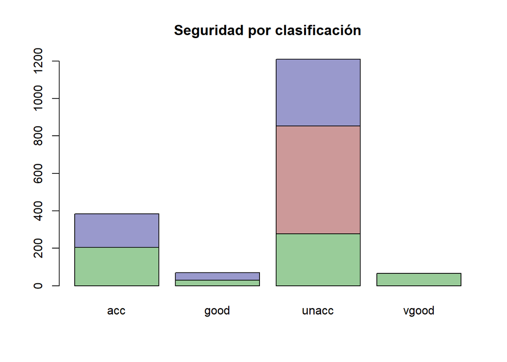

```r
#RESPUESTA

# Bar plot clasificando los class segun la frecuencia del tipo safety al cual pertenecen

x = table(data_tf$safety,data_tf$class)
barplot(x, main = "Seguridad por clasificación",col = c("#99cc99", "#cc9999", "#9999cc", "#9c9c9c"))
```